# Interpreting correlations

Lab 4D

Directions: Follow along with the slides, completing the questions in **blue** on your computer, and answering the questions in **red** in your journal.  
Space, Click, Right Arrow or swipe left to move to the next slide.

# Some background…

- So far, we’ve learned about measuring the success of a model based on how close its predictions come to the actual observations.
- The *correlation coefficient* is a tool that gives us a fairly good idea of how these predictions will turn out without having to make predictions on future observations.
- For this lab, we will be using the `movie` dataset to investigate the following question:

*Which variables are better predictors of a movie’s `critics_rating` when the predictions are made using a line of best fit?*

# Correlation coefficients

- The *correlation coefficient* describes the *strength* and *direction* of the linear trend.
- It’s only useful when the trend is linear and both variables are numeric.

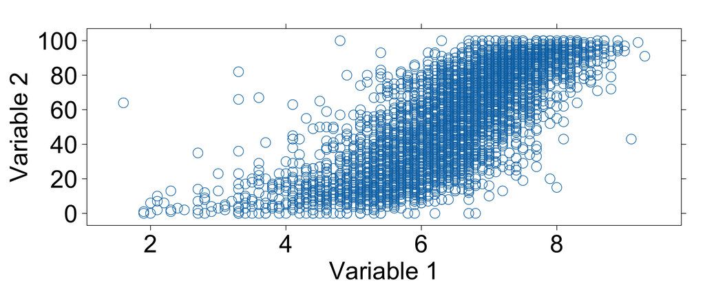

- **Are these variables linearly related? Why or why not?**

# Correlation review I

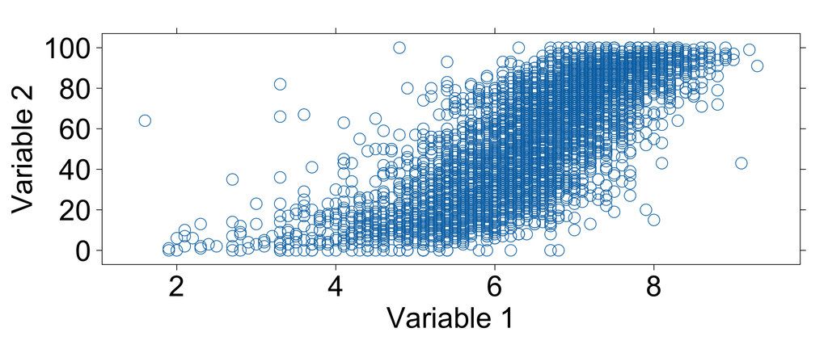

- Correlation coefficients with values close to 1 are very strong with a positive slope. Values close to -1 means the correlation is very strong with a negative slope.
- **Does this plot have a positive or negative correlation?**

# Correlation review II

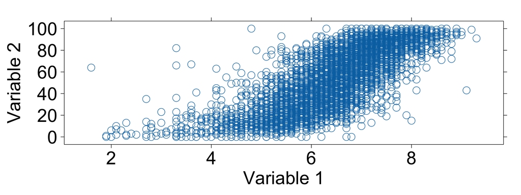

- Recall that if there is no linear relation between two numerical variables, the correlation coefficient is close to 0.
- **What do you guess the correlation coefficient will be for these two variables?**

# The movie data

- Load the `movie` data using the `data` command.
- The data comes from a variety of sources like *IMDB* and *Rotten Tomatoes*.
  - The `critics_rating` contains values between 0 and 100, 100 being the best.
  - The `audience_rating` contains values that range between 0 and 10, 10 being the best.
  - `n_critics` and `n_audience` describe the number of reviews used for the ratings.
  - `gross` and `budget` describe the amount of money the film made and took to make.

# Calculating correlation coefficients!

- We can use the `cor()` function to find the particular correlation coefficient of the variables from the previous plot, which happen to be `audience_rating` and `critics_rating`.
- But note, the `cor()` function removes any observations which contain an `NA` value in either variable.
- Calculate the correlation coefficient for these variables using the `cor` function. The inputs to the functions work just like the inputs of the `xyplot` function.

# Now answer the following

- **What was the value of the correlation coefficient you calculated?**
- **How does this actual value compare with the one you estimated previously?**
- **Does this indicate a strong, weak, or moderate association? Why?**
- **How would the scatterplot need to change in order for the correlation to be stronger?**
- **How would it need to change in order for the correlation to be weaker?**

# Correlation and Predictions

- Find the two variables that look to have the strongest correlation with `critics_rating`.
  - Compute the correlation coefficients for `critics_rating` and each of the two variables.
  - **Use the correlation coefficient to determine which variable has a stronger linear relationship with `critics_rating`.**
- Fit two `lm` models to predict `critics_rating` with each variable and compute the MSE for each.
  - **Use the MSE to determine which variable is a better predictor of `critics_rating`.**
- **How are the correlation coefficient and the MSE related?**

# On your own

- Select two different numerical variables from the `movie` data. Plot the variables using the `xyplot()` function.
  - **Would calculating a correlation coefficient for the two variables be appropriate? Justify your answer.**
  - **Predict what value you think the correlation coefficient will be. Compare this value to the actual value. Finally, interpret what the actual correlation coefficient means.**
- **Work with your classmates to determine which two variables have the strongest correlation coefficient.**
  - **Why do you think these variables are so strongly related? Is using the correlation coefficient to describe the relationship appropriate and why/why not?**